# Desafio Ciência de Dados - Indicium

Juliana Beker Godoy

2025-02-03

# Análise Exploratória

```
## 'data.frame':    48894 obs. of  15 variables:
##  $ id                           : num  2595 3647 3831 5022 5099 ...
##  $ nome                         : chr  "Skylit Midtown Castle" "THE VILLAGE OF HARLEM....NEW YORK !" "Cozy Entire Floor of Brownstone" "Entire Apt: Spacious Studio/Loft by central park" ...
##  $ host_id                      : num  2845 4632 4869 7192 7322 ...
##  $ host_name                    : chr  "Jennifer" "Elisabeth" "LisaRoxanne" "Laura" ...
##  $ bairro_group                 : chr  "Manhattan" "Manhattan" "Brooklyn" "Manhattan" ...
##  $ room_type                    : chr  "Entire home/apt" "Private room" "Entire home/apt" "Entire home/apt" ...
##  $ latitude                     : num  40.8 40.8 40.7 40.8 40.7 ...
##  $ longitude                    : num  -74 -73.9 -74 -73.9 -74 ...
##  $ price                        : num  225 150 89 80 200 60 79 79 150 135 ...
##  $ minimo_noites                : num  1 3 1 10 3 45 2 2 1 5 ...
##  $ disponibilidade_365          : num  355 365 194 0 129 0 220 0 188 6 ...
##  $ numero_de_reviews            : num  45 0 270 9 74 49 430 118 160 53 ...
##  $ reviews_por_mes              : num  0.38 NA 4.64 0.1 0.59 0.4 3.47 0.99 1.33 0.43 ...
##  $ calculado_host_listings_count: num  2 1 1 1 1 1 1 1 4 1 ...
##  $ ultima_review                : Date, format: "2019-05-21" NA ...
```

## Avaliando as variáveis individualmente

### Bairro

Os bairros do Brooklyn e Manhattan possuem a maior quantidade de imóveis disponíveis para locação em comparação com o bairro do Queens, Bronx e Staten Island.

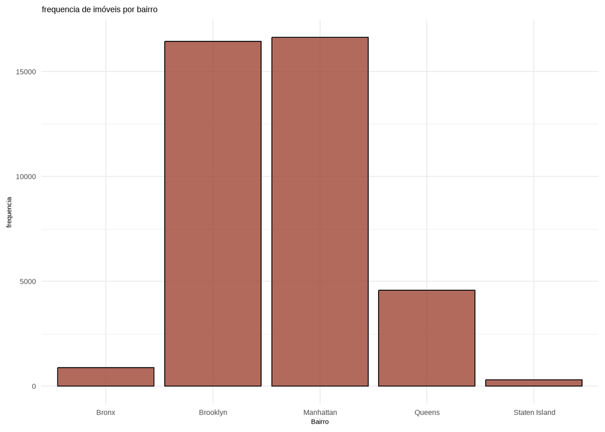

#### Densidade de imóveis por bairro

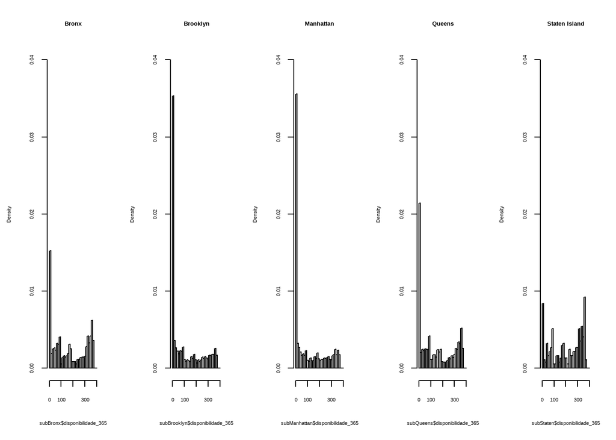

### Tipos de acomodação

Há poucos quartos compartilhados neste conjunto de dados. Os apartamentos inteiros e os quartos privativos se destacam pela sua frequencia.

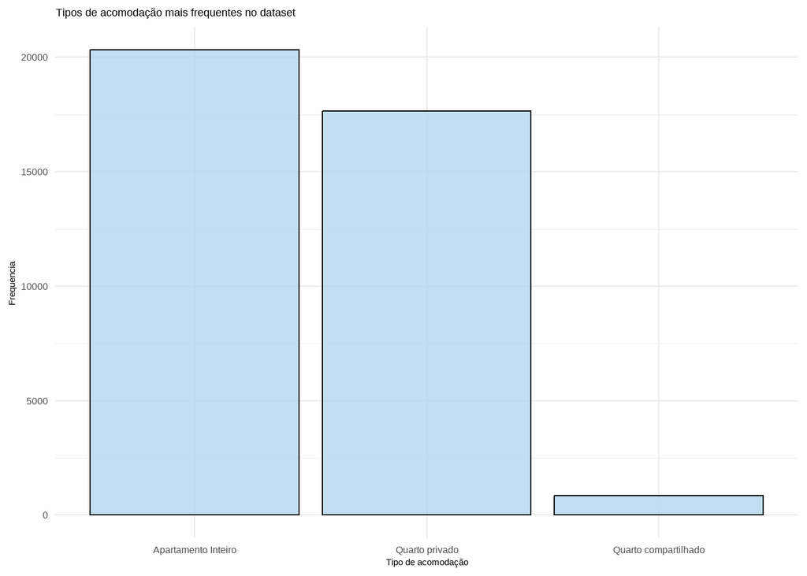

### Preço por noite (USD)

As acomodações inteiras possuem maior valor agregado quando comparados ao outros dois tipos de imóveis disponíveis nos dados (quarto privado e compartilhado).

```
##       0%      25%      50%      75%      95%      99%     100%
##     0.00    69.00   101.00   170.00   330.10   671.62 10000.00
```

```
## [1] "Media de preço dos imóveis para aluguel por noite(USD): 130.850147016731"
```

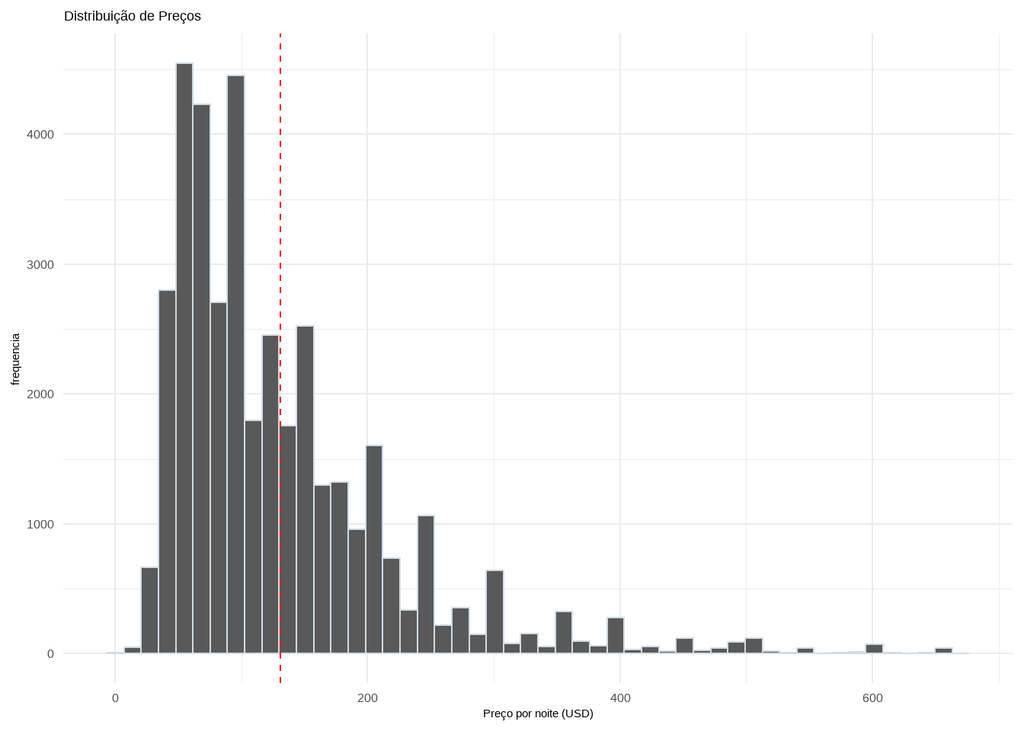

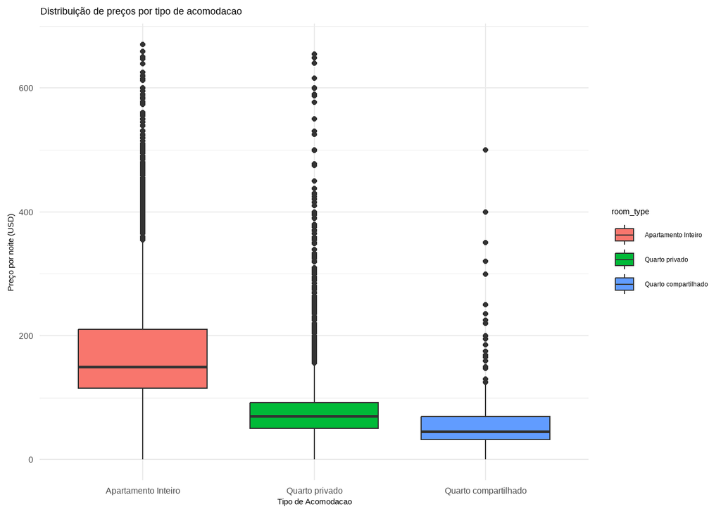

### Mínimo de noites

```
##   0%  25%  50%  75%  95%  99% 100%
##    1    1    2    4   30   31 1250
```

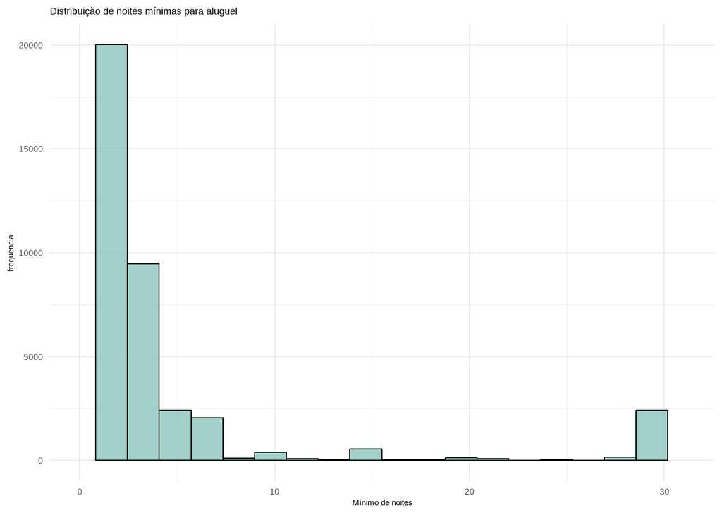

```
## [1] 90.28004
```

### Disponibilidade ao longo do ano

32% das acomodações ficam indisponíveis durante todo o ano. Porém, mais de um terço do conjunto de dados (40%) ficam disponíveis por mais de 100 dias no mercado.

```
##   0%  15%  30%  50%  75%  95% 100%
##    0    0    0   53  225  355  365
```

```
## [1] 32.93828
```

```
## [1] 40.14107
```

```
## [1] 27.00456
```

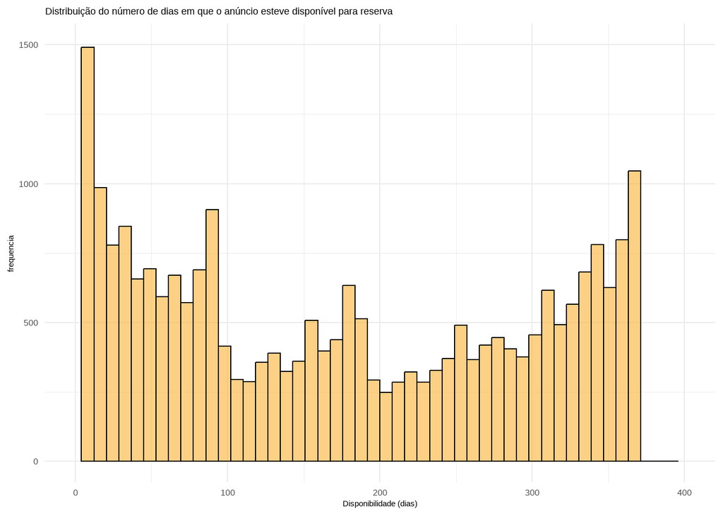

### Número de reviews

Todos os imóveis possuem no mínimo uma avaliação e, ao todo, 52% do todos imóveis possuem até 10 avaliações.

```
##   0%  25%  50%  75%  95%  99% 100%
##    1    3   10   34  129  228  629
```

```
## [1] 98.34024
```

```
## [1] 13.39609
```

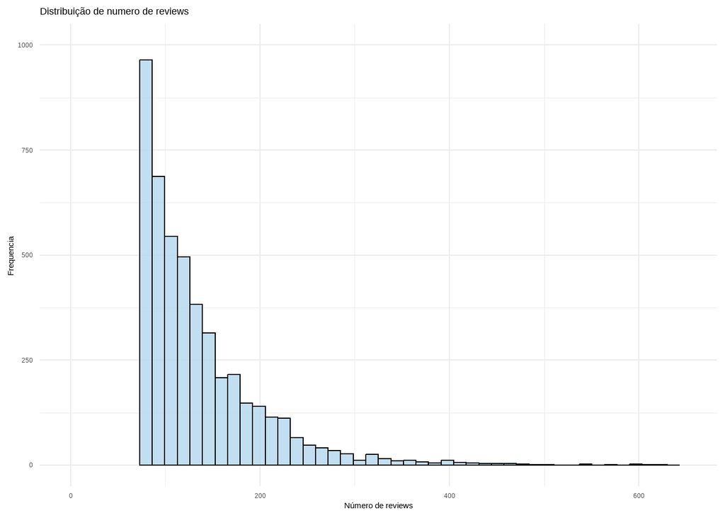

### Data do último review

Majoritariamente, as reviews são do ano de 2019.

```
##  Factor w/ 9 levels "2011","2012",..: 9 9 8 9 9 7 9 9 9 9 ...
```

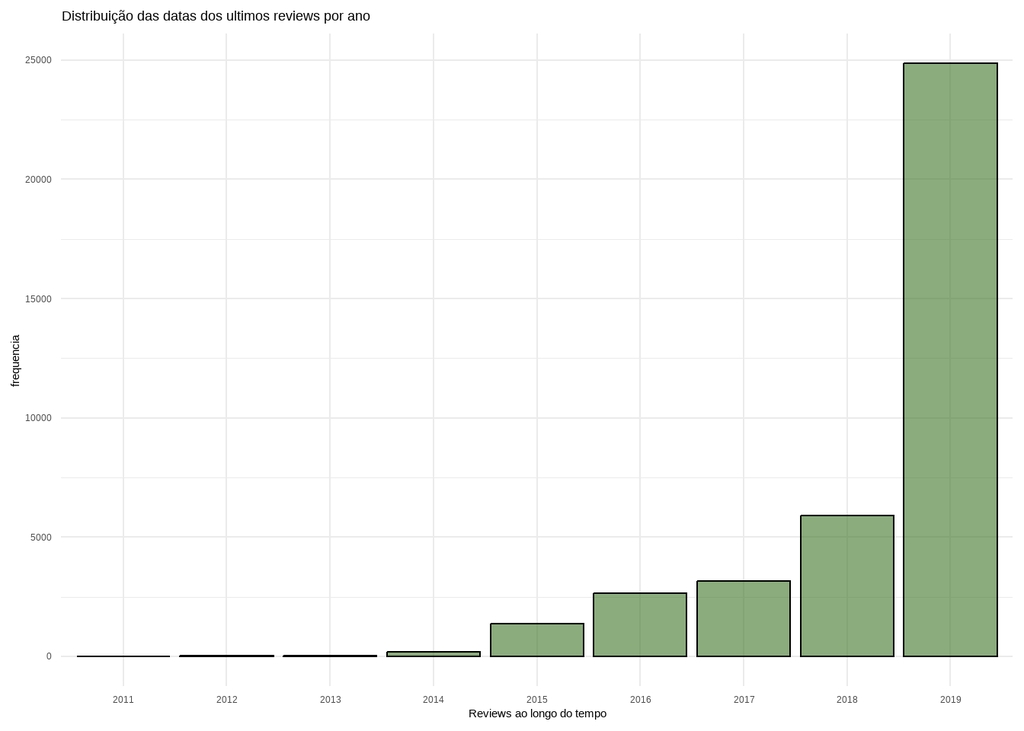

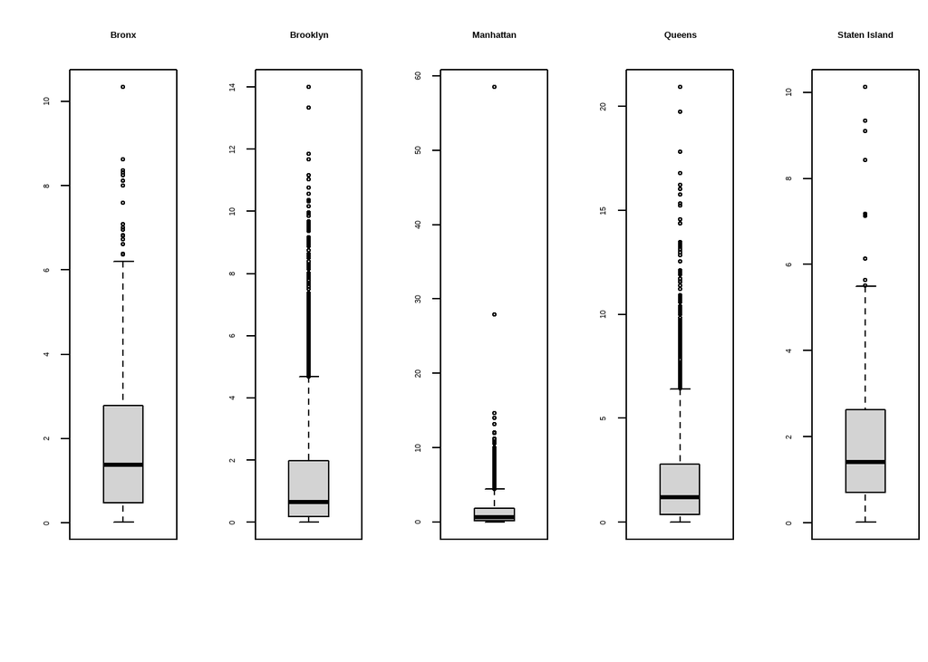

### Quantidade de imóveis por locatário

A maioria dos locatários (75%) possuem apenas um imóvel para locação.

```
##   0%  25%  50%  75%  95%  99% 100%
##    1    1    1    1    3    6  327
```

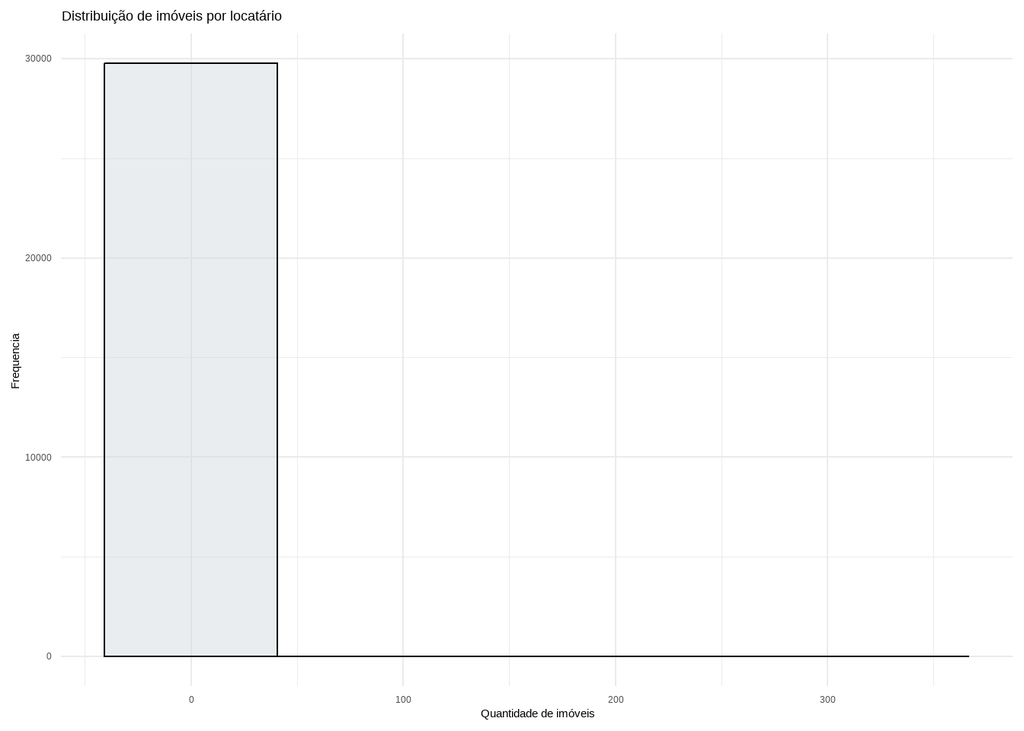

### Palavras mais comuns

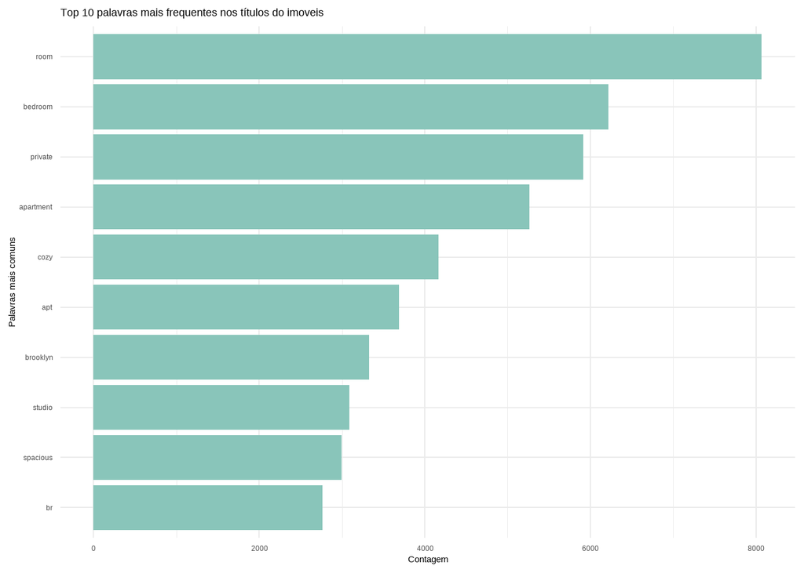

## Avaliação das variáveis par a par

Como esperado, a média dos reviews possui alto correlação com a quantidade de reviews. Esta última foi mantida no conjunto de dados uma vez que o coeficiente de correlação absoluto foi ligeiramente maior em relação à variável alvo (preço).

### Correlação entre as variáveis normalizadas

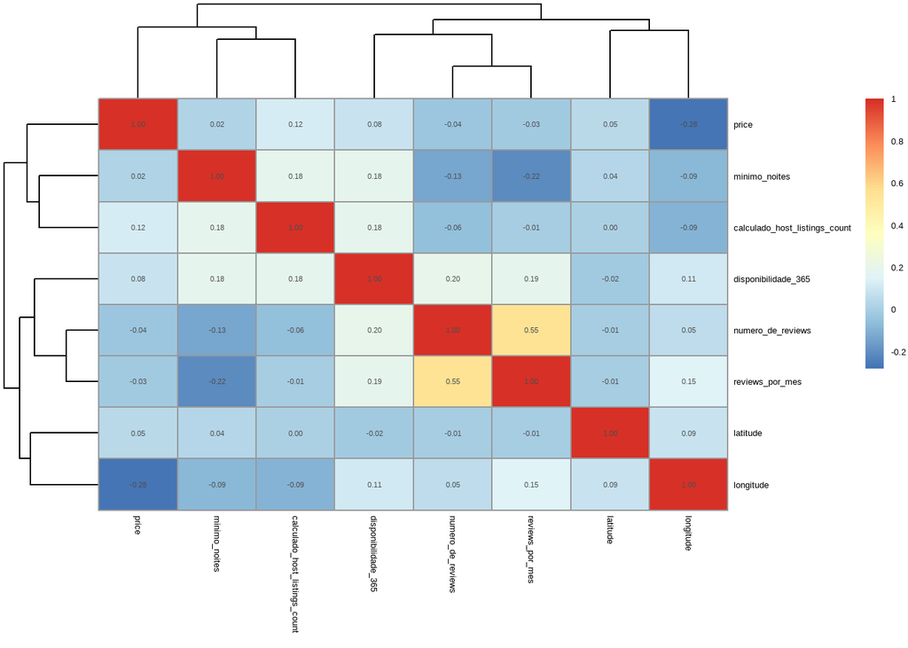

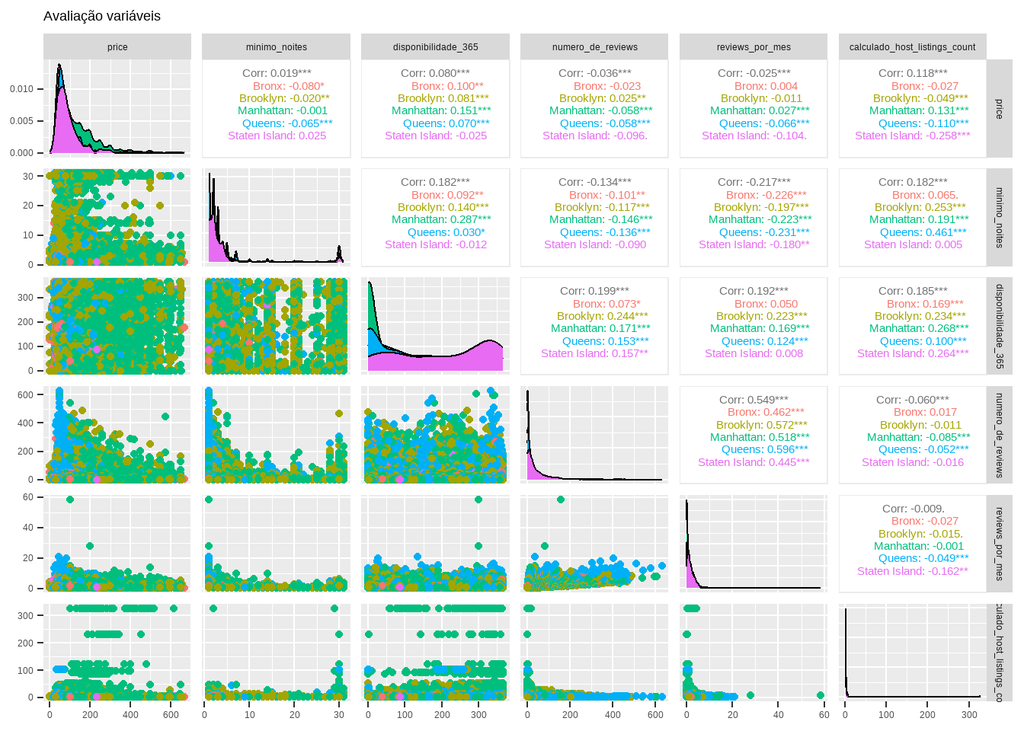

### Média de preços por noite por acomodação por bairro

Os apartamentos inteiros possuem maior preço médio por noite em todos os bairros, com destaque para Manhattan.

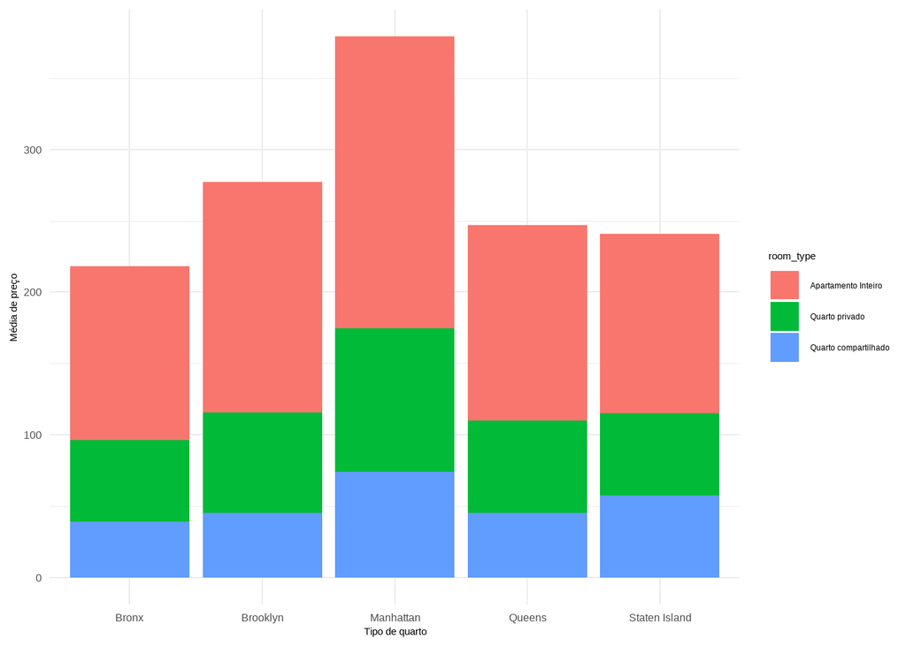

### A disponibilidade do imóvel está correlacionada com o número de reviews?

A quantidade de reviews está positivamente associada a disponibilidade ao longo do ano

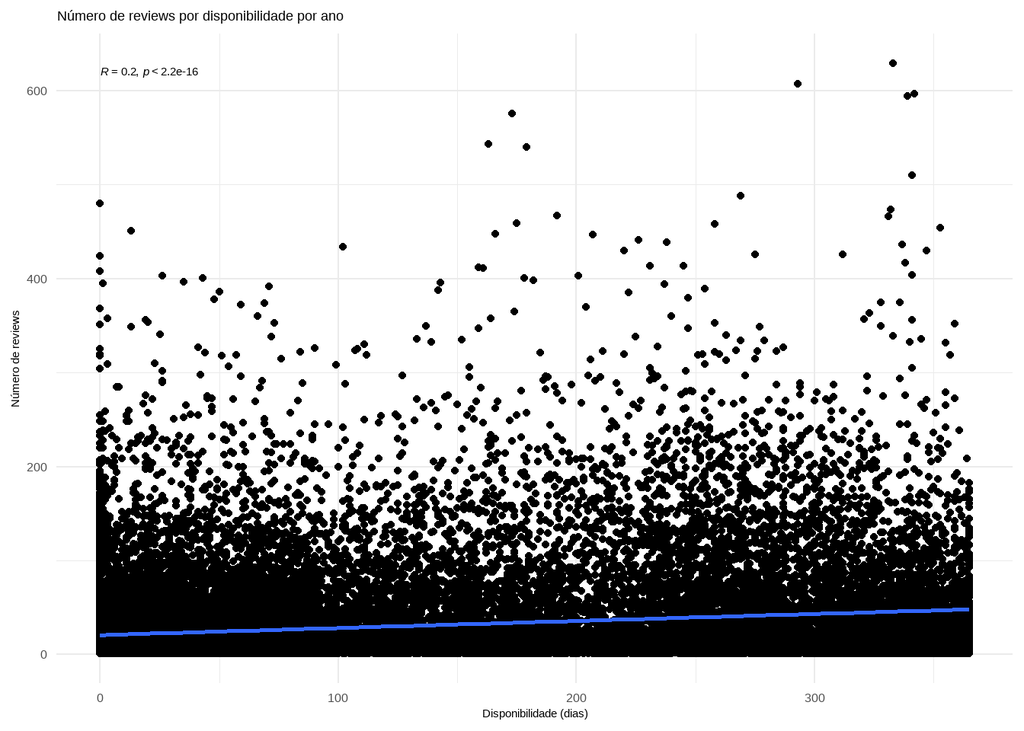

### A disponibilidade está correlacionada o preço por noite?

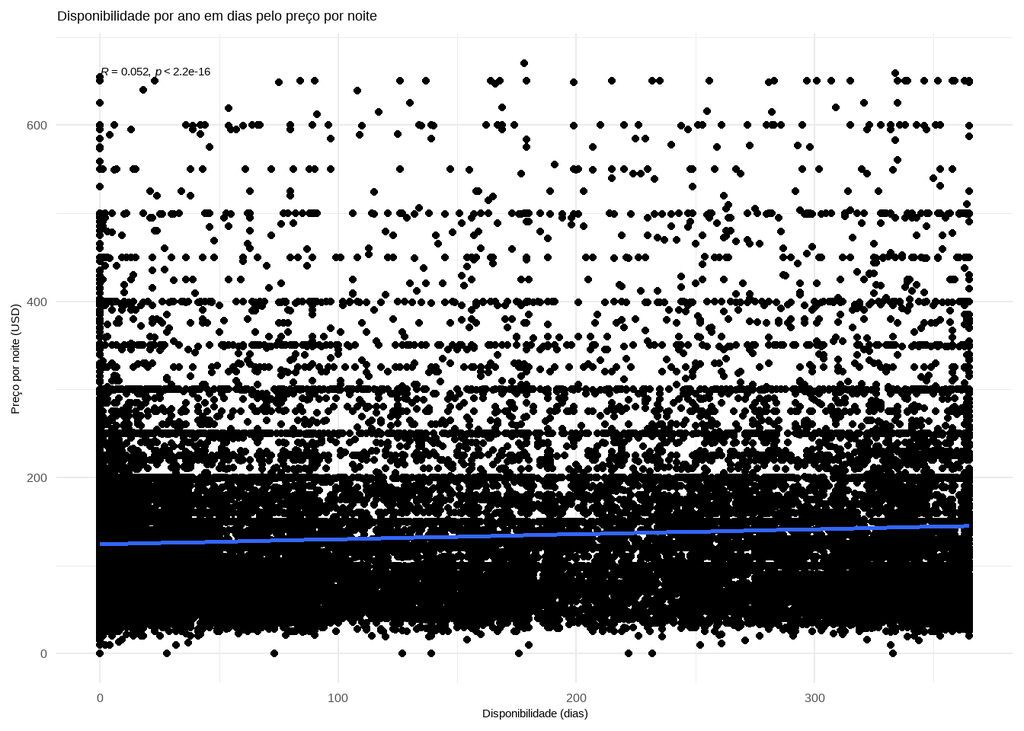

## Em qual bairro devo comprar?

De acordo com as análises abaixo Manhattan é a melhor escolha para a compra de impoveis para aluguéis de curta temporada em NY.

### Tempo de disponibilidade do imóvel no mercado

Os imóveis localizados no bairro de Staten Island possuem o maior tempo médio de disponibilidade no mercado, seguido do Bronx e Queens.

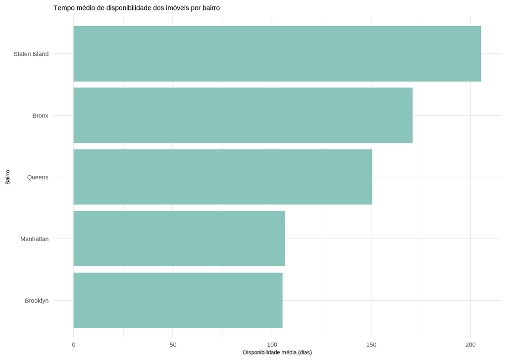

### Imóveis indisponíveis durante todo o ano

Manhattan e Brooklyn possuem a maior quantidade de imóveis indisponíveis durante todo o ano e que alugam mais rápido durante o ano (menos de 10 dias).

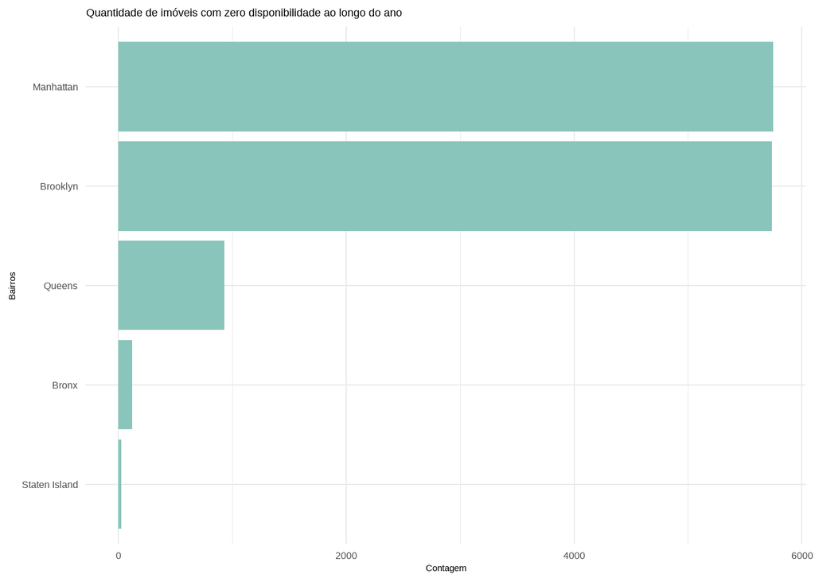

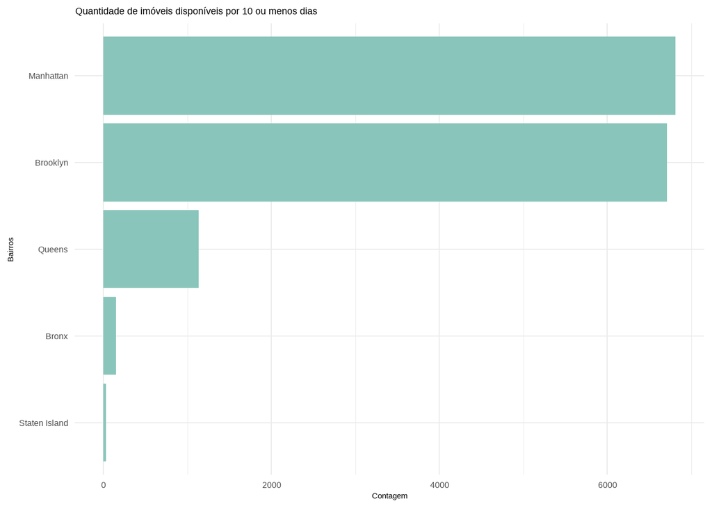

### Preço por noite médio (USD)

Manhattan possui a maior média de preços por noite (USD) em comparação aos outros bairros.

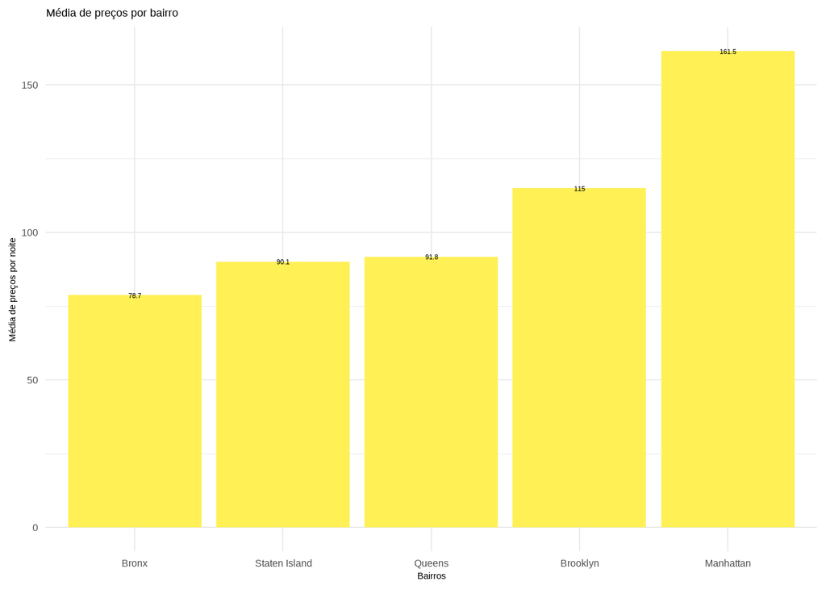

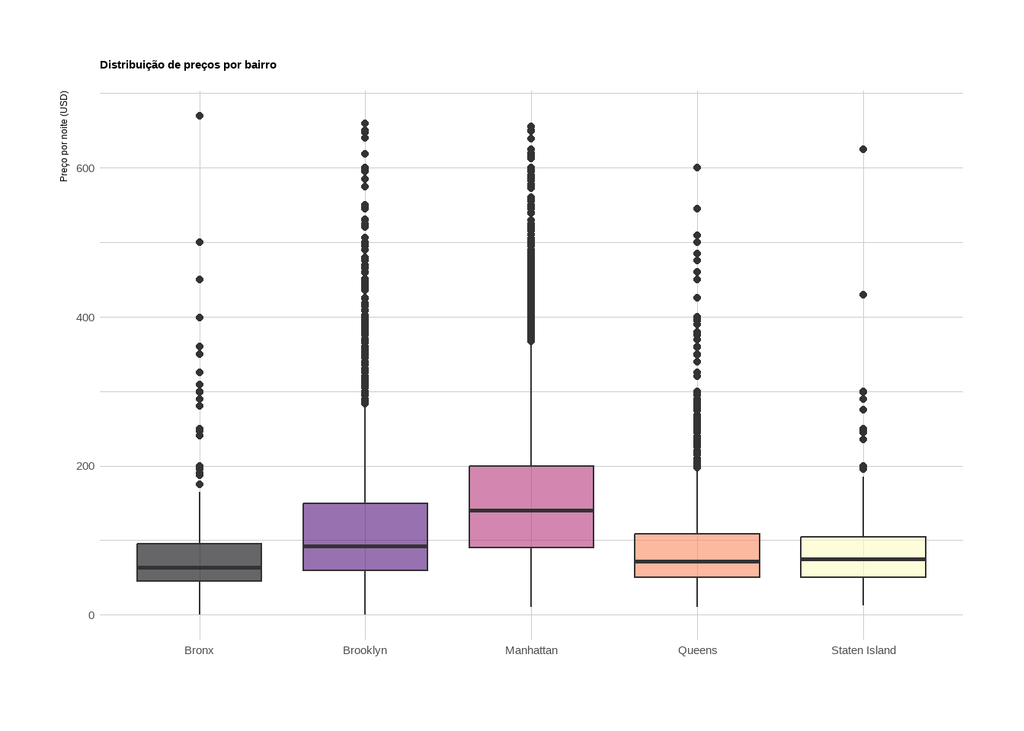

## Há padrão no texto do nome do local para imóveis de alto custo?

```
## [1] "skylit"  "midtown" "castle"  "cozy"    "entire"  "floor"
```

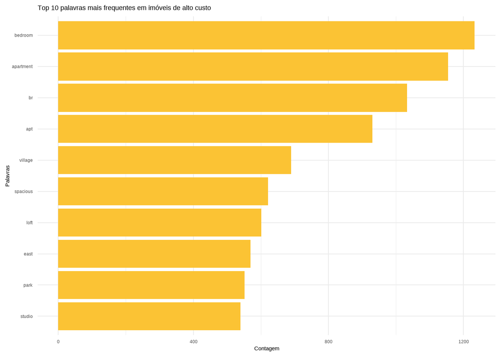

```
## replace the existing one.
```

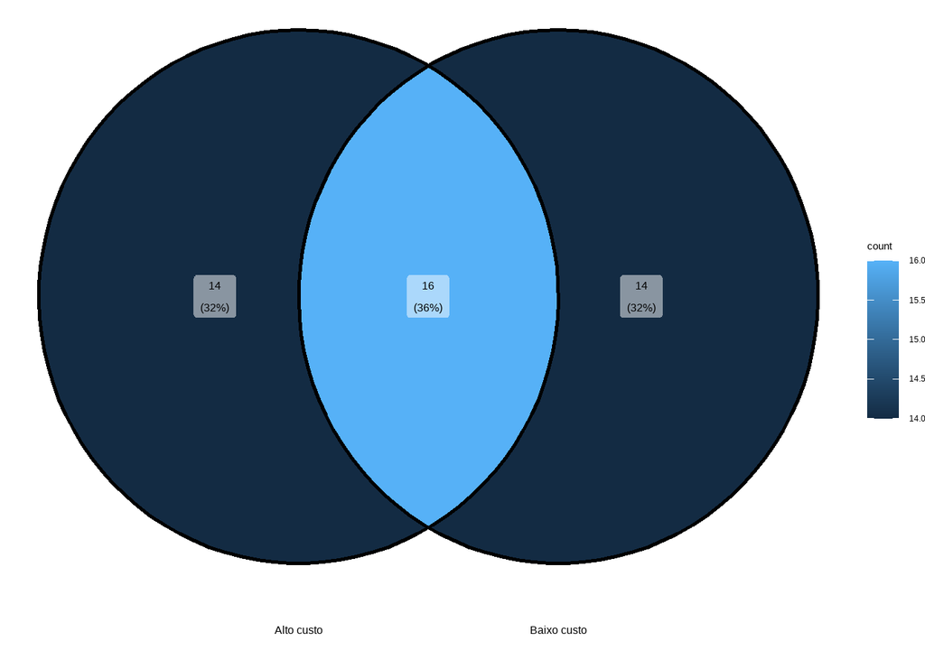

```
## [1] 0
```

# Modelos

Foram testados 3 modelos de regressão para a previsão de preços de aluguel por noite. Os conjunto de dados fornecido, foi dividido em 70% em dados para treinamento dos modelos e 30% em dados para teste.

## Árvore de decisão

Este modelo obteve os melhores resultados de previsão. A porcentagem de erro nos dados de treinamento foi de 18% e utilizando os dados de teste foi de 26%.

```
##      price              bairro_group                  room_type
##  Min.   :  0.0   Bronx        :  596   Apartamento Inteiro :13920
##  1st Qu.: 69.0   Brooklyn     :11431   Quarto privado      :12210
##  Median :100.0   Manhattan    :11269   Quarto compartilhado:  566
##  Mean   :131.2   Queens       : 3170
##  3rd Qu.:165.0   Staten Island:  230
##  Max.   :670.0
##
##     latitude       longitude      minimo_noites    disponibilidade_365
##  Min.   :40.51   Min.   :-74.24   Min.   : 1.000   Min.   :  0
##  1st Qu.:40.69   1st Qu.:-73.98   1st Qu.: 1.000   1st Qu.:  0
##  Median :40.72   Median :-73.95   Median : 2.000   Median : 53
##  Mean   :40.73   Mean   :-73.95   Mean   : 4.978   Mean   :114
##  3rd Qu.:40.76   3rd Qu.:-73.93   3rd Qu.: 4.000   3rd Qu.:228
##  Max.   :40.91   Max.   :-73.71   Max.   :31.000   Max.   :365
##
##  numero_de_reviews calculado_host_listings_count ano_ultima_review
##  Min.   :  1.00    Min.   :  1.000               2019   :17415
##  1st Qu.:  3.00    1st Qu.:  1.000               2018   : 4160
##  Median :  9.00    Median :  1.000               2017   : 2194
##  Mean   : 29.54    Mean   :  5.268               2016   : 1806
##  3rd Qu.: 34.00    3rd Qu.:  2.000               2015   :  945
##  Max.   :629.00    Max.   :327.000               2014   :  125
##                                                  (Other):   51
##     previsao
##  Min.   : 24.65
##  1st Qu.: 72.73
##  Median :114.00
##  Mean   :131.21
##  3rd Qu.:173.33
##  Max.   :514.71
##
```

```
##  10%  25%  50%  75%  90%
## 0.03 0.08 0.18 0.34 0.55
```

```
##    Min. 1st Qu.  Median    Mean 3rd Qu.    Max.
##    0.00    0.08    0.18     Inf    0.34     Inf
```

```
##      price              bairro_group                 room_type
##  Min.   :  0.0   Bronx        : 270   Apartamento Inteiro :5863
##  1st Qu.: 66.0   Brooklyn     :4826   Quarto privado      :5309
##  Median :100.0   Manhattan    :4894   Quarto compartilhado: 270
##  Mean   :130.2   Queens       :1369
##  3rd Qu.:165.0   Staten Island:  83
##  Max.   :659.0
##
##     latitude       longitude      minimo_noites    disponibilidade_365
##  Min.   :40.54   Min.   :-74.17   Min.   : 1.000   Min.   :  0.0
##  1st Qu.:40.69   1st Qu.:-73.98   1st Qu.: 1.000   1st Qu.:  0.0
##  Median :40.72   Median :-73.95   Median : 2.000   Median : 53.0
##  Mean   :40.73   Mean   :-73.95   Mean   : 4.892   Mean   :112.4
##  3rd Qu.:40.76   3rd Qu.:-73.93   3rd Qu.: 4.000   3rd Qu.:220.0
##  Max.   :40.91   Max.   :-73.73   Max.   :31.000   Max.   :365.0
##
##  numero_de_reviews calculado_host_listings_count ano_ultima_review
##  Min.   :  1.00    Min.   :  1.000               2019   :7435
##  1st Qu.:  3.00    1st Qu.:  1.000               2018   :1734
##  Median : 10.00    Median :  1.000               2017   : 948
##  Mean   : 29.44    Mean   :  4.927               2016   : 826
##  3rd Qu.: 33.00    3rd Qu.:  2.000               2015   : 412
##  Max.   :597.00    Max.   :327.000               2014   :  66
##                                                  (Other):  21
##     previsao
##  Min.   : 24.65
##  1st Qu.: 71.56
##  Median :112.33
##  Mean   :130.16
##  3rd Qu.:171.93
##  Max.   :514.71
##
```

```
##  10%  25%  50%  75%  90%
## 0.05 0.12 0.26 0.48 0.77
```

```
##    Min. 1st Qu.  Median    Mean 3rd Qu.    Max.
##    0.00    0.12    0.26     Inf    0.48     Inf
```

```
## [1] "A previsão do preço para aluguel por noite(USD) para o imóvel da questão 4 é de: 238.294117647059"
```

## Regressão Linear Multivariada

O modelo construído utilizando regressão linear não foi tão eficaz já que o R-squared foi de 0.40.

```
##
## Call:
## lm(formula = price ~ . - ano_ultima_review, data = df_treino)
##
## Residuals:
##     Min      1Q  Median      3Q     Max
## -171.61  -39.79  -11.01   19.67  565.54
##
## Coefficients:
##                                 Estimate Std. Error  t value Pr(>|t|)
## (Intercept)                   -2.378e+04  1.319e+03  -18.035  < 2e-16 ***
## bairro_groupBrooklyn          -7.523e+00  3.692e+00   -2.038   0.0416 *
## bairro_groupManhattan          2.911e+01  3.350e+00    8.689  < 2e-16 ***
## bairro_groupQueens             7.148e+00  3.543e+00    2.017   0.0437 *
## bairro_groupStaten Island     -1.111e+02  6.823e+00  -16.287  < 2e-16 ***
## room_typeQuarto privado       -9.248e+01  9.034e-01 -102.373  < 2e-16 ***
## room_typeQuarto compartilhado -1.246e+02  3.051e+00  -40.847  < 2e-16 ***
## latitude                      -8.393e+01  1.310e+01   -6.407 1.50e-10 ***
## longitude                     -3.701e+02  1.484e+01  -24.945  < 2e-16 ***
## minimo_noites                 -1.522e+00  6.153e-02  -24.737  < 2e-16 ***
## disponibilidade_365            1.145e-01  3.634e-03   31.499  < 2e-16 ***
## numero_de_reviews             -1.115e-01  9.287e-03  -12.006  < 2e-16 ***
## calculado_host_listings_count  9.439e-02  1.685e-02    5.603 2.13e-08 ***
## ---
## Signif. codes:  0 '***' 0.001 '**' 0.01 '*' 0.05 '.' 0.1 ' ' 1
##
## Residual standard error: 70.8 on 26683 degrees of freedom
## Multiple R-squared:  0.4013, Adjusted R-squared:  0.401
## F-statistic:  1490 on 12 and 26683 DF,  p-value: < 2.2e-16
```

```
## [1] 0.4012521
```

```
## [1] 0.4009828
```

```
##    Min. 1st Qu.  Median    Mean 3rd Qu.    Max.
##  -36.11   79.19  139.04  131.21  181.00  286.23
```

```
##    Min. 1st Qu.  Median    Mean 3rd Qu.    Max.    NA's
##      NA      NA      NA     NaN      NA      NA       1
```

```
##    Min. 1st Qu.  Median    Mean 3rd Qu.    Max.
##  -36.11   79.19  139.04  131.21  181.00  286.23
```

```
##    Min. 1st Qu.  Median    Mean 3rd Qu.    Max.
##  -26.03   77.85  134.48  130.30  180.68  286.21
```

```
##    Min. 1st Qu.  Median    Mean 3rd Qu.    Max.    NA's
##      NA      NA      NA     NaN      NA      NA       1
```

```
##    Min. 1st Qu.  Median    Mean 3rd Qu.    Max.
##  -26.03   77.85  134.48  130.30  180.68  286.21
```

## Random Forest

O R-squared desse modelo foi alto utilizando os dados de treinamento: 0.86. Porém, ao utilizar os dados de teste a eficiencia do modelo caiu consideravelmente, 0.50.

```
##           [,1]
## [1,] 0.8628923
```

```
##           [,1]
## [1,] 0.5063189
```